# An introduction to R markdown for reproducible research

```
Stephen J Eglen                  Cambridge Computational Biology Institute
https://sje30.github.io          University of Cambridge
sje30@cam.ac.uk                  @StephenEglen
```

Slides: http://bit.ly/eglen2018-rmd (CC-BY license)

#### Acknowledgements

Laurent Gatto, Mike Smith.

(Last update Thu Jul  4 22:42:57 2019)

## Literate programming

Donald Knuth invented the literate programming environment to combine
code and documentation into one file.

In our context, we interweave R code and markdown.  R code is executed
and results (text, figures, tables) fed back into markdown.  Markdown
then translated into html (or pdf or Word or slides...).

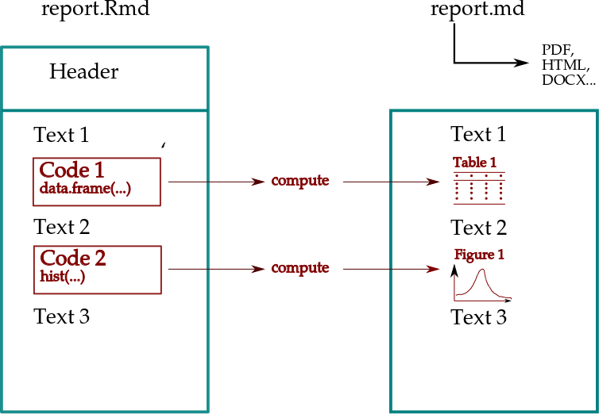

## Simple example of reproducible research

Eglen SJ (2016) Bivariate spatial point patterns in the retina: a
reproducible review. Journal de la Société Française de Statistique
157:33–48.

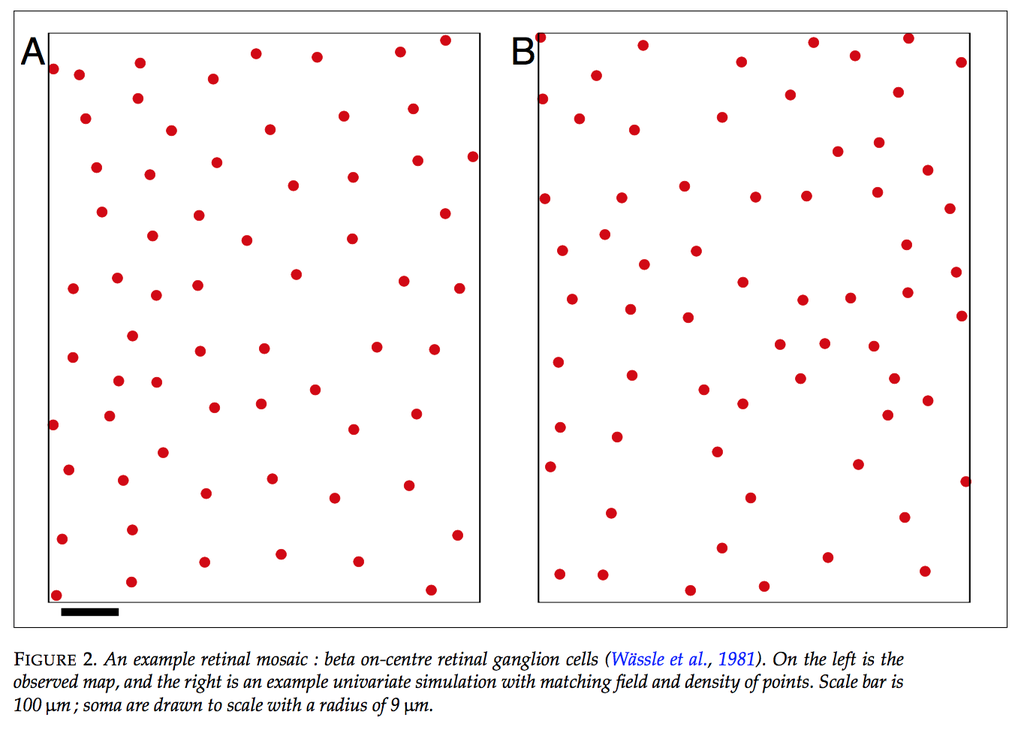

See

[paper](https://doi.org/10.1101/029348)
or [code](http://github.com/sje30/eglen2015).  [Docker image](https://hub.docker.com/r/sje30/eglen2015/).

See other examples at: <https://rmarkdown.rstudio.com/gallery.html>

## What is markdown?

A light-weight markup language for generating HTML.

```
### Example

Here is some *markup text* with **bold** and a
[link](http://www.rstudio.org).
Maths can be included $x^2 + y^2 = z^2$.
```

### Example

Here is some *markup text* with **bold** and a
[link](http://www.rstudio.org).
Maths can be included `\(x^2 + y^2 = z^2\)`.

## Embedding code: inline

Take a chunk like:

Simple snippets of code can be embedded like ‘r sqrt(144)‘ is the
square root of 144.

(NB: the backtick character above.)

which makes:

Simple snippets of code can be embedded like 12 is the
square root of 144.

## Embedding code: chunks

Or a chunk of code

```{r eval=TRUE}
    n = 10
    rnorm(n)
    ```

which makes this output:

```r
n = 10
rnorm(n)
```

```
##  [1] -0.97356414  0.20996956 -0.85973078 -0.15349797  0.56438390
##  [6] -0.60281258  1.61592802 -0.04732354  1.41106328 -1.10988931
```

## Figures

If your code generates a figure, it is saved into `figures/` folder
and included in output.  (See bookdown for captions and references).

‘‘‘{r eval=TRUE, echo=TRUE, fig.height=4}
    x = rnorm(300, mean=4, sd=2)
    hist(x)
    ‘‘‘

```r
x = rnorm(300, mean=4, sd=2)
hist(x)
```

[figure not shown]

## Reproducible figures

Never mind making a whole paper reproducible, how about just one figure?

```r
library(ggplot2); library(patchwork) # github.com/thomasp85/patchwork
p1 = ggplot(mtcars) + geom_point(aes(mpg, disp)) + labs(tag="A")
p2 = ggplot(mtcars) +
  geom_boxplot(aes(gear, disp, group = gear)) + labs(tag="B")
p3 = ggplot(mtcars) + geom_smooth(aes(disp, qsec)) + labs(tag="C")
p4 = ggplot(mtcars) + geom_bar(aes(carb)) + labs(tag="D")
((p1 | p2 | p3) /  p4 ) + theme_bw()
```

[figure not shown]

## Won't this be slow?

Q: "If R is always re-running the analysis every time I edit my paper,
won't this be slow?"

A: Yes.  In which case, use the **cache**.

## Rstudio demonstration

Create a new document with a simple structure.  See header and options
for compiling document.

## Bookdown

Bookdown sits atop knitr and provides extra features for writing a
book (captioning figures and tables, labels to refer to sections).

<https://bookdown.org/>  <https://bookdown.org/yihui/bookdown/>

## Challenges

* Long computation times (CODE CHECK).
* licensed software complicates everything.
* Can journals handle reproducible documents?
* When is the best time to think reproducibly?
   - Too early (explore  first)
   - Too late (paper now out)?
* Technical challenges << Societal challenges

## Extended example

You will need `estimatek.Rmd` and `refs.bib`

(References are in BiBTeX format; you can get them from google
scholar, or e.g. from <https://www.bioinformatics.org/texmed/> which
is pubmed with BiBTeX.)

## rticles

The `rticles` package allows you to make Rmd templates for a growing
number of journals, easing the adoption of formatting for journals.

<https://github.com/rstudio/rticles>

## Next steps

* Material from today at: <http://github.com/sje30/2018-12-07-rmd>
* Jupyter <www.jupyter.org> as alternative format for notebook
  computation.
* Two-way Rmd <-> docx conversion: <https://noamross.github.io/redoc/>
* officedown <https://github.com/davidgohel/officedown>
* pandoc toolkit <https://pandoc.org/> drives a lot of conversion from
  markdown into other formats (EPUB, Word, PDF, XML...)